# Método dos trapézios

### **Autor**: Osvaldo César Cuba Margato

#### Linguagem utilizada: Python 3.6

## Introdução

Pelo teorema fundamental do cálculo, seja *f* uma função contínua no intervalo *[a, b]*, temos que:

\begin{equation}\int_{a}^{b} f(x) dx = F(b) - F(A)\end{equation}

em que, *F(x)* é uma função primitiva de *f(x)*. A partir disso, podemos afirmar que a integral definida dessa função representa a área *A* abaixo da curva e pode ser denotada como:

\begin{equation}A = \int_{a}^{b} f(x) dx\end{equation}

**Visualização geométrica:**

[figure not shown]

Saber a área de uma curva é muito útil no mundo real, como definir o trabalho *W* de uma força a partir do deslocamento em *x* metros. Ao descobrir a área da curva temos o trabalho, ou seja, devemos integrar a força em relação ao deslocamento. \begin{equation}W = \int_{a}^{b} f(x) dx\end{equation}

## Motivação

Algumas funções não possuem uma função primitiva, logo, pelos teoremas e postulados, não é possível resolver.

### Exemplo

A função erro (ou função erro de Gauss) é uma função não-elementar muito usada em estatística. \begin{equation} erf(x) = \dfrac{2}{\sqrt\pi} \int_{0}^{t} e^{-x^2} dx = \dfrac{1}{\sqrt\pi} \int_{-t}^{t} e^{-x^2} dx \end{equation}

A função: \begin{equation} \int_{-t}^{t} e^{-x^2} dx \end{equation} Não possui uma função primitiva, então para esse caso, podemos aplicar o **método dos trapézios** para calcular a área embaixo da curva.

## Definição

Dado um intervalo *[a, b]* e *n* iterações, podemos aproximar a área *A* da curva pela área de trapézios.

[figure not shown]

**Função geral:**

\begin{equation} \text{Área dos trapézios } = A_i = \dfrac{h}{2}[f(x_0) + 2(f(x_1) + ... + f(x_{n-1})) + f(x_n)] \\ \text{Sendo } h = \dfrac{b-a}{n} \end{equation}

**Para calcular a área exata, subtraimos o erro do método:** \begin{equation} \text{Área exata } = A = A_i - \dfrac{h^3}{12} f''(\xi) \\ \text{Sendo }\xi \text{ um número entre a e b} \end{equation}

### Aplicação:

Nesse trabalho, o método foi aplicado na função abaixo, no intervalo *[-1, 1]*: \begin{equation} \int_{a}^{b} e^{-x^2} dx \end{equation}

# Programa para descobrir a área da integral através do método

## Inicialização

```python
%matplotlib inline
import numpy as np
import pandas as pd
import math
import matplotlib.pyplot as plt

def f(x):
    # f(x) = e^(-x²)
    return math.exp(-x**2)

a = float(input("A: "))
b = float(input("B: "))
n = int(input("Iterações: "))
n = n + 1
h = float((b - a) / n)

ys = []
xs = np.linspace(a, b, n, endpoint=True).tolist()
print(f"Intervalo: [{a}, {b}], iterações: {n - 1}, passo: {h}")
for xi in xs:
    ys.append(f(xi))
points = {
    'x': xs,
    'y': ys
}
df = pd.DataFrame(points)
df.index = df.index + 1
```

```
A: -1
B: 1
Iterações: 10
Intervalo: [-1.0, 1.0], iterações: 10, passo: 0.18181818181818182
```

# Pontos gerados

```python
# Tabela (DataFrame) dos pontos
df
```

|  | x | y |
| --- | --- | --- |
| 1 | -1.0 | 0.367879 |
| 2 | -0.8 | 0.527292 |
| 3 | -0.6 | 0.697676 |
| 4 | -0.4 | 0.852144 |
| 5 | -0.2 | 0.960789 |
| 6 | 0.0 | 1.000000 |
| 7 | 0.2 | 0.960789 |
| 8 | 0.4 | 0.852144 |
| 9 | 0.6 | 0.697676 |
| 10 | 0.8 | 0.527292 |
| 11 | 1.0 | 0.367879 |

# Função que retorna a área da curva pelo método dos trapézios

```python
def trapezes(h, ys):
    y_sum = sum(ys[1:(n - 1)])
    return (h/2) * (ys[0] + ys[-1] + 2 * y_sum)
```

# Gráfico

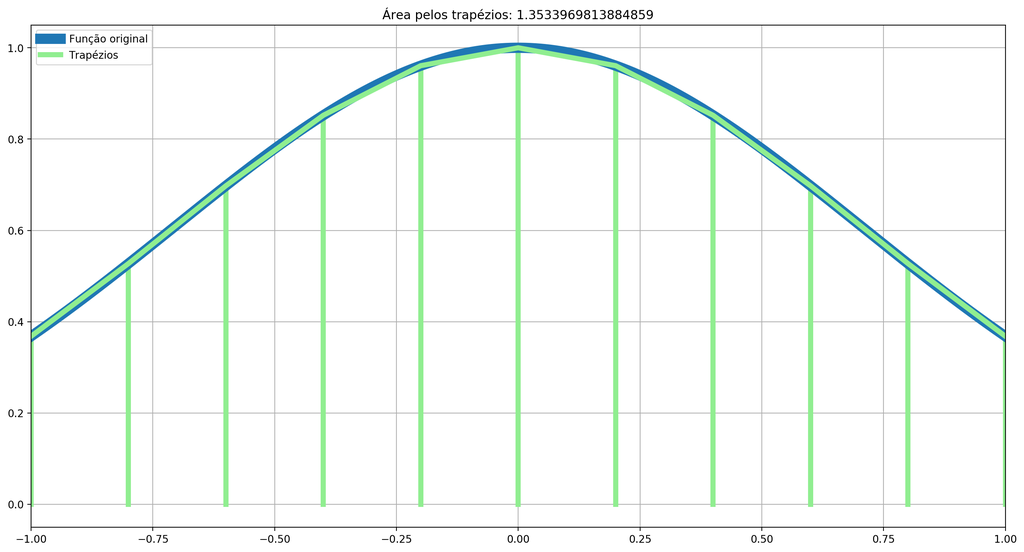

```python
_xs = np.linspace(a, b, 1000, endpoint=True).tolist()
_ys = [f(_x) for _x in _xs]

fig = plt.gcf()
fig.set_dpi(200)
fig.set_size_inches(17,9)

plt.xlim(a, b)
for i in range(len(xs)):
    plt.plot([xs[i], xs[i]], [0, ys[i]], color="lightgreen",linewidth=5)
plt.plot(_xs, _ys, label="Função original", linewidth=10)
plt.plot(xs, ys, color="lightgreen", label="Trapézios", linewidth=5)
plt.title("Área pelos trapézios: " + str(trapezes(h, ys)))
plt.grid()
plt.legend(loc='upper left')
plt.show()
```

# Aplicando a função, temos:

```python
print('h:', h)
print('Valor da integral da função:', trapezes(h, ys))
```

```
h: 0.18181818181818182
Valor da integral da função: 1.3533969813884859
```

# Comparando o número de iterações

No exemplo abaixo, vemos o quão impreciso fica o cálculo da área com poucas iterações.

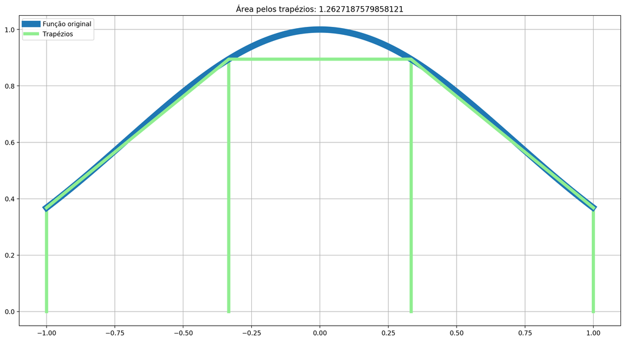

```python
n_test = 4 # 3 iterações, 4 pontos
h_test = float((b - a) / n_test)
ys_test = []
xs_test = np.linspace(a, b, n_test, endpoint=True).tolist()
for xi in xs_test:
    ys_test.append(f(xi))
points_test = {
    'x': xs_test,
    'y': ys_test
}
df_test = pd.DataFrame(points_test)
df_test.index = df_test.index + 1
df_test

fig = plt.gcf()
fig.set_dpi(200)
fig.set_size_inches(17,9)

_xs_test = np.linspace(a, b, 1000, endpoint=False).tolist()
_ys_test = [f(_x) for _x in _xs_test]
for i in range(len(xs_test)):
    plt.plot([xs_test[i], xs_test[i]], [0, ys_test[i]], color="lightgreen",linewidth=5)
plt.plot(_xs_test, _ys_test, label="Função original", linewidth=10)
plt.plot(xs_test, ys_test, color="lightgreen", label="Trapézios", linewidth=5)
plt.grid()
plt.legend(loc='upper left')
plt.title("Área pelos trapézios: " + str(trapezes(h_test, ys_test)))
plt.show()
```

# Referências bibliográficas

**Trapezoidal rule**  
Disponivel em: https://en.wikipedia.org/wiki/Trapezoidal_rule. Acesso em: 27 nov. 2019.  
**Regra dos trapézios**  
Disponivel em: https://sites.google.com/site/calcnum10/home/lista-5/metodos/regra-dos-trapezios. Acesso em: 27 nov. 2019.